# FUSIÓN TELECOM Y TELEFÓNICA

AUDINET REPORT  
La fusión de Telecom y Telefónica

[figure not shown]

¿Cómo impacta al mercado de Internet?

La empresa del Grupo Clarín invirtió US$ 1.245 millones para quedarse con Telefónica Argentina.  
La operación marca un hito histórico en el mercado argentino de telecomunicaciones.

[figure not shown]

[interactive chart not shown]

Así se distribuye el Market Share en Argentina previo a la adquisición.  
Flow (Telecom) y Movistar (Telefónica) son dos de los principales players dentro del mercado.

[interactive chart not shown]

¿Cómo es la presencia de Movistar en el mercado?  
Según el relevamiento de Fabric, Movistar tiene cobertura en 14 provincias.

El 81% de sus abonados se concentran en CABA, Buenos Aires y Mendoza.

[interactive chart not shown]

Mientras que las provincias donde Movistar tiene una posición más dominante en el market share se encuentran en la región patagónica.

Estas son Río Negro (45.6%), Chubut (43.6%), Tierra del Fuego (37.2%) y Neuquén (36.2%).

En estas provincias del sur, Movistar alcanza sus mayores niveles de participación de mercado, llegando al 45.6% en Río Negro y 43.6% en Chubut.

[interactive chart not shown]

¿Cómo quedaría reconfigurada la presencia de Flow en el mercado?  
Actualmente Flow es el líder en el mercado de Internet en Argentina con 3.9 millones de abonados y 34.68% de Market Share.

Tiene presencia en 23 provincias.

Hoy en día Flow es **LÍDER DE MERCADO** en 13 de esas provincias.

[figure not shown]

[interactive chart not shown]

Tras la fusión, Flow pasaría a ser **LÍDER DE MERCADO** en 17 de esas provincias y tendría cobertura en todas las provincias del país.

Veamos en detalle el impacto de la fusión en el Market Share de Flow.

Este sería el impacto de la fusión en el Market Share de Flow si le sumamos el Share de Movistar en las provincias donde comparten cobertura.

Tras la fusión, el Market Share de Flow en dichas provincias se vería así.  
En distritos como CABA (53.9%), Neuquén (46.7%), San Juan (51.2%) y Río Negro (54.8%), la empresa de Telecom pasaría a tener una posición totalmente dominante.

[interactive chart not shown]

A nivel nacional, Flow lidera el mercado con un 34.7% de participación, seguido por Claro con 15.1%. Movistar, que será adquirida por Flow, actualmente tiene un 12.9% del mercado.

Tras la fusión, Flow alcanzará un 47.5% del mercado nacional, lo que lo convertirá en el líder indiscutido del sector. El siguiente competidor más cercano mantendrá un 15.1% de participación.

[interactive chart not shown]

¿Será beneficiosa la fusión para los abonados? ¿Podrán acceder a una mejor calidad del servicio a menor precio?  
• Flow ofrece solo 3 planes desde 100MB hasta 1000MB con precios entre $43.000 y $81.000  
• Movistar tiene una oferta más diversificada con velocidades desde 100MB hasta 1000MB y precios más bajos, desde $31.390 hasta $46.090.

[interactive chart not shown]

Según lo presentado, los usuarios de Flow pagan $228 por MB, mientras que los usuarios de Movistar acostumbran a pagar valores menores, de $125 por MB. La adquisición de Movistar por parte de Flow podría acarrear un incremento de precios a los usuarios de Movistar.  
En este contexto, queda por evaluar si a futuro se produce un cambio de proveedor de aquellos que se vean perjudicados.

[interactive chart not shown]

ANÁLISIS REALIZADO POR  
AUDINET

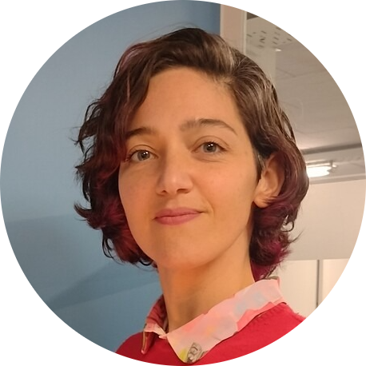

Jimena Municoy

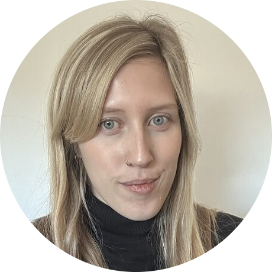

Thelma Fratarelli

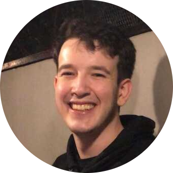

Pablo Cerchia